# Annotations HowTo

M. Calciu

4/18/2021

# Using Annotation in order to do sentiment analysis on COVD19-TweetIDs-FR

In this document we show how to use the data available on this directory in order to do sentiment analysis on the COVD19-TweetIDs that are being published on this site (french language tweets).

## Downloading and preparing files for analysis

This preparation phase uses essentially system bash commands First, in order to accelerate calculations, it is recomandable to clone our github site COVID19-TweetIDs-Fr on your local computer using the following command: git clone https://github.com/calciu/COVID19-TweetIDs-Fr. Suppose site has been cloned in the current users downloads directory (usually ~/Downloads/) to open this HowTo with RStudio, you should point to the ~/Downloads/COVID19-TweetIDs-Fr/CovidAnnot directory and once opened make shure that this remain the current working directory for the R console.

### Recompose splitted annotation and helper files

As github repositories cannot contain files bigger than 25 Mb and later 50 Mb some annotions and helper files had to be split and need to be recomposed in order to facilitate further calculations. This job is done in the CovidAnnot directory using a simple bash commands pipeline.

```bash
cat date09fr_1.csv date09fr_2.csv  > date09fr.csv # regroupes splitted files into one
cat date10fr_1.csv date10fr_2.csv date10fr_3.csv > date10fr.csv # regroupes splitted files into one
cat date11fr_1.csv date11fr_2.csv  > date11fr.csv # regroupes splitted files into one
rm d*_?.csv # remove splitted files

cat ids09fr_1.csv ids09fr_2.csv  > ids09fr.csv # regroupes splitted files into one
cat ids10fr_1.csv ids10fr_2.csv  > ids10fr.csv # regroupes splitted files into one
cat ids11fr_1.csv ids11fr_2.csv  > ids11fr.csv # regroupes splitted files into one
rm i*_?.csv # remove splitted files

cat nrc09fr_1.csv nrc09fr_2.csv  > nrc09fr.csv # regroupes splitted files into one
cat nrc10fr_1.csv nrc10fr_2.csv  > nrc10fr.csv # regroupes splitted files into one
cat nrc11fr_1.csv nrc11fr_2.csv  > nrc11fr.csv # regroupes splitted files into one
rm n*_?.csv # remove splitted files
```

### Regroup monthly helper files into files covering the whole analysed period

In order to rapidly cover the whole analysed period from month 01 (January) to month 11 (November) 2020, all monthly files may be regrouped. For helper files it is straighforward as they are headless (meaning the they don’t have a header as field name).

```bash
cat  date1-5fr.csv date06fr.csv date07fr.csv date08fr.csv date09fr.csv date10fr.csv date11fr.csv > _date1-11fr.csv
rm d* # remove monthly files
cat ids1-5fr.csv  ids06fr.csv ids07fr.csv ids08fr.csv ids09fr.csv ids10fr.csv ids11fr.csv > _ids1-11fr.csv
rm i* # remove monthly files
cat twtype1-5fr.csv twtype06fr.csv twtype07fr.csv twtype08fr.csv twtype09fr.csv twtype10fr.csv twtype11fr.csv > _twtype1_11fr.csv
rm t* # remove monthly files
```

### Regroup monthly annotation files into files covering the whole analysed period

For annotation files it is more complicated as each monthly file has field names (headers) which need to be eliminated when adding them one after the other. Finally removing the underscore in the name of the annotation file helps distinguish annotation from helper files.

```bash
cat nrc1-5fr.csv > _nrc1-11fr.csv && tail -n+2 -q nrc??fr.csv >> _nrc1-11fr.csv
rm n* # remove monthly files
mv _nrc1-11fr.csv  nrc1-11fr.csv # remove the underscore in front of the file name
```

### Some quick file statistics distinguishing annotation and helper files

Counting the lines of the remaining files in the directory we can see the number of tweets that can be analysed

```bash
wc -l * # count the lines (tweets) of the files
```

```
##      138 HowTo.Rmd
##  16199643 _date1-11fr.csv
##  16199643 _ids1-11fr.csv
##  16199643 _twtype1_11fr.csv
##  1500000 emoji1-5fr_1.csv
##   681719 emoji1-5fr_2.csv
##  2181719 lsd1-5fr.csv
##  16199644 nrc1-11fr.csv
##  69162149 total
```

There are 16199643 Tweets that can be identified by their unique identifiers (ids), creation date (date ..) and type (twtype ..). The annotion files (here nrc ..) contain an additional header line with field names indicating emmotions and sentiment frequencies for each tweet.

## Sentiment Analysis using annotation files

This phase uses R commands to do the analysis. As the files are rather big and as the purpose of this document is only demostrative we use a sample of 100 Ktweets for the remaining calculations.

```r
df <- read_csv("_date1-11fr.csv", col_names = FALSE) # read tweets creation dates
```

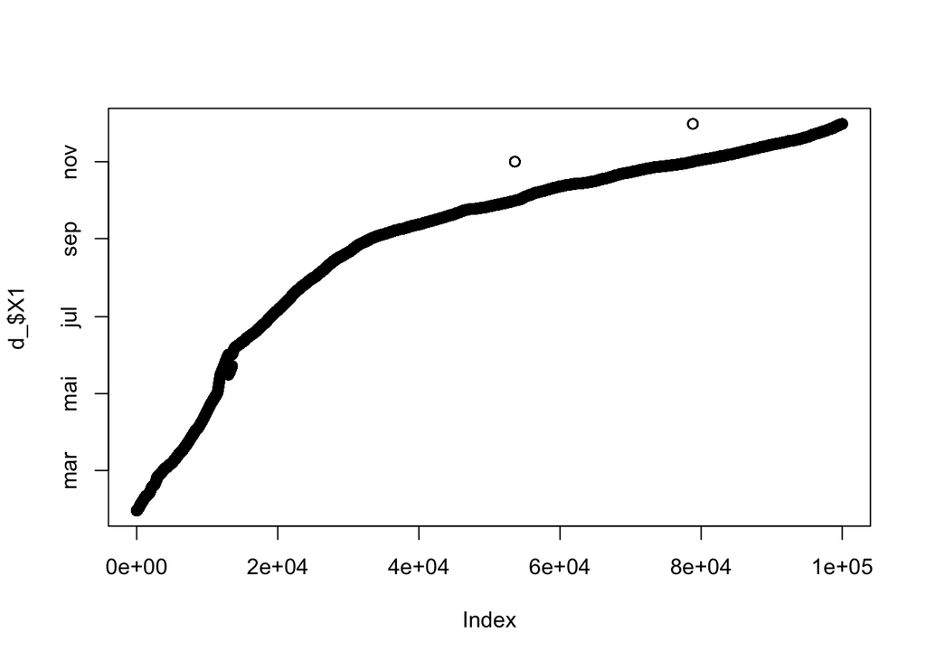

```r
sp <- sort(sample(as.numeric(rownames(df)), 100000)) # extract a sample ordered by creation dates
d_ <- df[sp,]
plot(d_$X1)
```

The plot plot reveals a problem in our data. It shows that there are some redundant data in the second half of mai. Probably tweets of the month Mai need to be hydrated again. We will communicate the changes when operated.

### Tweet types

```r
df <- read_csv("_twtype1_11fr.csv", col_names = FALSE) # read tweets creation dates
```

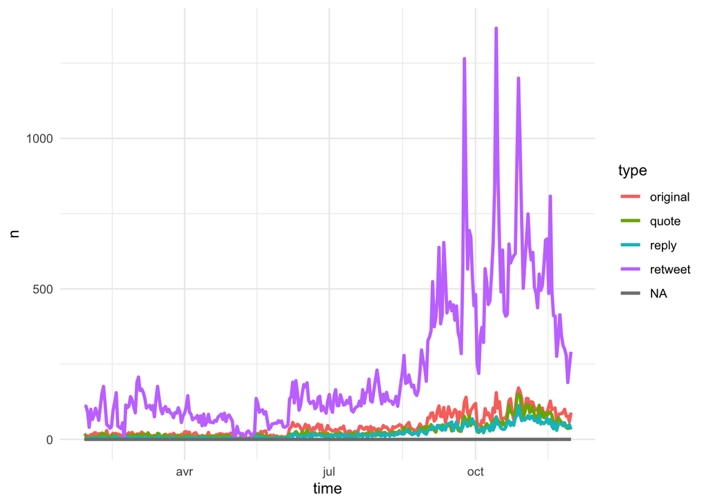

```r
t_ <- df[sp,]
dt_ = cbind(d_,t_)
names(dt_)=c("date","type")
dt_ %>%
  group_by(type) %>%
ts_plot( "1 day", lwd=1.1) +
  ggplot2::theme_minimal()
```

### Tweet sentiments and emotions

```r
df <- read_csv("nrc1-11fr.csv") # read tweets creation dates
df_nrc <- df[sp,]
df_nrc <- cbind(dt_, df_nrc)
df_nrc$day<-as.numeric(format(df_nrc$date, "%d"))
df_nrc$month<-as.numeric(format(df_nrc$date, "%m"))
df_nrc$hour<-as.numeric(format(df_nrc$date, "%H"))

emoevol<-df_nrc %>% filter(type=="original") %>% group_by(month,day,hour) %>% mutate(n=1) %>%
  summarise(anger=mean(anger,na.rm=TRUE),
            anticipation=mean(anticipation, na.rm=TRUE),
            disgust=mean(disgust, na.rm=TRUE),
            fear=mean(fear, na.rm=TRUE),
            joy=mean(joy, na.rm=TRUE),
            sadness=mean(sadness, na.rm=TRUE),
            surprise=mean(surprise, na.rm=TRUE),
            trust=mean(trust, na.rm=TRUE),
            n=sum(n))
```

[figure not shown]

```r
emoevol$date<-paste0("2020","-",emoevol$month,"-",emoevol$day," ",emoevol$hour,":00:00")
emoevol$date2 <- as.POSIXct(strptime(emoevol$date, "%Y-%m-%d %H:%M:%S"))
foo<-emoevol %>% ungroup %>%select(date2, anger,fear,disgust, sadness ,surprise,anticipation,trust, joy )
emocol<-c("red3","orangered1","purple3","royalblue3","chartreuse","olivedrab3","green4","yellow")
library(reshape2)
foo<-melt(foo, id=c("date2"))
ggplot(foo, aes(x=date2,y=value,group=variable))+
  geom_line(size=1,aes(color=variable),show.legend = FALSE)+
  theme(axis.text.x=element_text(angle = 90, vjust = 0.5))+
  theme_minimal()+ stat_smooth(method = "gam", aes(color=variable)  )+
  facet_wrap(vars(variable),ncol=4)+
  scale_color_manual(values=emocol)+  scale_x_datetime(date_breaks = "1 day", labels = scales::label_date_short())
```

```r
rm(list=ls())
```